# Porcentaje de grasa corporal en hombres. Un análisis exhaustivo

Al hablar de la información con la que vamos a trabajar, contamos con 252 datos en los cuales se registra el porcentaje de grasa corporal en hombres que es medido con la ayuda de datos como lo puede ser la edad, peso, altura, circunferencia tanto de pecho, abdomen, cadera, muslo, rodilla, tobillo, bicep, antebrazo, muñeca, etc.

Entonces, en base a estos datos, procederemos a hacer un modelo lineal generalizado

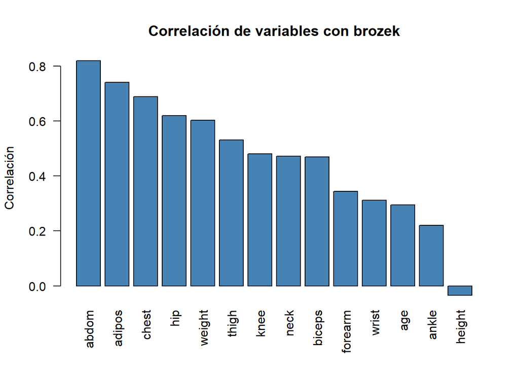

Gracias a lo visto en el chunk *r corrData* podemos ver que, en relación a la variable del porcentaje de grasa corporal en hombres, tendrá una gran correlación con los datos que nos hablan de las circunferencias (abdominal, pectoral, etc.) y adipos.

Ahora bien, para empezar a poder analizar nuestros diferentes modelos, tendremos que partiremos nuestros datos en dos, el 80% de ellos lo usaremos para poder entrenar nuestro modelo elegido y el 20% será para aplicar este modelo y estimar el poder de predicción, repitiéndolo 50 veces.

En el siguiente, nos adentraremos al siguiente modelos haciendo lo mismo que en el anterior, solamente que aquí consideraremos variables al cuadrado.

Después, haremos una selección de variables con el criterio de BIC

Ahora, como siguiente intento haremos una selección de variables con el método Lasso.

Finalmente, a la hora de hacer el último modelo, tenemos que será hacer una selección de variables de un modelo lineal generalizado de distribución gamma y liga identidad con variables al cuadrado.

Si representamos en una tabla los valores de cada medición para cada modelo, tenemos los siguientes valores:

Medidas de desempeño por modelo

| Modelo | MSE | MAE | R2 |
| --- | --- | --- | --- |
| Modelo 1 | 16.46 | 3.30 | 0.71 |
| Modelo 2 | 125.90 | 6.47 | 0.26 |
| Modelo 3 | 17.33 | 3.38 | 0.70 |
| Modelo 4 | 15.77 | 3.27 | 0.73 |
| Modelo 5 | 19.01 | 3.50 | 0.68 |

Notamos que hay algunas variables que se repiten en la mayoría de los modelos, las cuales parecen tener un mayor poder predictivo sobre el resto de variables. Dichas variables son: age, abdom, wrist y neck.

Si vamos modelo a modelo tendremos varias interpretaciones.

En el primero, gracias a lo visto en el R^2 por ejemplo, esto nos indica que el modelo parece ser un buen resultado y con ayuda de lo visto en el MSE y MAE podemos ver que no parece haber un problema de sobreajuste, por lo que a priori el modelo parece ser bueno.

Al ver el cuarto, vemos que para este modelo en todo mejora al primer modelo, tiene un menor MSE y MAE, lo cual indica mejoría y un mayor R^2 , lo cual nos hace decantarnos al modelo Lasso como el mejor modelo de todos, sobre todo porque al momento de ver el quinto modelo, no supera al Lasso.

De acuerdo con las métricas que usamos para evaluar el poder predictivo de los modelos, concluimos que el mejor modelo fue el 4to:

De acuerdo con las métricas que usamos para evaluar el poder predictivo de los modelos, concluimos que el mejor modelo fue el 4to:

$$\hat{y} = \beta_0 + \beta_1
(\text{abdom}) + \beta_2 (\text{age}) (\text{thigh}) + \beta_3
(\text{age}) (\text{ankle}) + \beta_4 (\text{age}) (\text{biceps}) +
\beta_5 (\text{height}) (\text{neck}) + \beta_6 (\text{height})
(\text{wrist})$$
$$+ \beta_7
(\text{neck}) (\text{wrist}) + \beta_8 (\text{abdom})
(\text{forearm})$$

Al hablar acerca del poder predictivo, el modelo elegido, es decir, el Lasso muestra un buen poder predictivo, pues no solo agarrará las variables más relevantes, sino que también minimiza el riesgo de sobreajuste.